# Holonomy diagnostics for hierarchical MCMC

fibr package

2026-06-04

## The problem

Standard MCMC diagnostics — R-hat, ESS, divergence counts — detect *whether* a chain has mixed. They do not tell you *why* it has not. For hierarchical models, the geometric answer is often that the parameter space has a **fiber bundle structure** whose curvature creates a transport obstruction that vanilla HMC does not account for.

The two-level logistic model makes this concrete.

$$y_{ij} \sim \text{Bernoulli}\!\left(\text{logit}^{-1}(\alpha_i +
x_{ij}^\top\beta)\right),
\quad
\alpha_i \sim \mathcal{N}(\mu,\sigma^2)$$

The joint parameter space $(\mu,\sigma,\alpha_1,\ldots,\alpha_J,\beta)$ has a natural **fiber bundle** decomposition:

- **Base** $B$: hyperparameters $(\mu,\sigma)$
- **Fiber** $F$: group intercepts $(\alpha_1,\ldots,\alpha_J)$

The Fisher information metric on the total space has off-diagonal blocks $G_{BF}$ coupling base and fiber. These blocks define an **Ehresmann connection**: they tell you which fiber directions are “horizontal” (driven by the base) vs. “vertical” (genuine fiber variation). When the base traverses a closed loop, the connection’s **curvature** means the fiber returns to a rotated or contracted version of its starting point. This is the **holonomy** — and it is what makes the centred parameterisation hard for NUTS in the funnel regime.

fibr provides three tools:

| Function | What it computes |
| --- | --- |
| `holonomy_diagnostic()` | Statistical fiber memory at loop endpoints |
| `compute_connection()` | Analytic Fisher metric blocks G_FF, G_BF, curvature |
| `smoothbp_advisor()` | Per-group prior_frac for smoothbp changepoint RE |

## Simulating the toy model

We use a sparse GLMM (J = 8 groups, n_j = 3 obs each, $\sigma = 3$) where the centred parameterisation genuinely struggles.

```r
set.seed(123)
J          <- 8L
n_j        <- 3L
N          <- J * n_j
mu_true    <- 0
sigma_true <- 3       # wide prior → strong funnel
beta_true  <- c(0.8, -0.5)

alpha_true <- rnorm(J, mu_true, sigma_true)
group_id   <- rep(seq_len(J), each = n_j)
X          <- matrix(rnorm(N * 2L), ncol = 2L)
eta        <- alpha_true[group_id] + X %*% beta_true
y          <- rbinom(N, 1L, plogis(eta))

stan_data <- list(N = N, J = J, group = group_id, X = X, y = y)
cat(sprintf("N = %d, J = %d, mean(y) = %.2f\n", N, J, mean(y)))
```

```
#> N = 24, J = 8, mean(y) = 0.42
```

```r
cat(sprintf("alpha range: [%.1f, %.1f]\n", min(alpha_true), max(alpha_true)))
```

```
#> alpha range: [-3.8, 5.1]
```

## Fitting the centred GLMM

We fit using **cmdstanr** with short chains for vignette speed. Replace `iter_sampling` and `iter_warmup` with larger values in practice.

```r
library(cmdstanr)
# Resolve Stan file whether running from installed package or source tree
stan_file <- system.file("stan", "glmm_centred.stan", package = "fibr")
if (!nzchar(stan_file)) {
  pkg_root <- normalizePath(
    if (nzchar(Sys.getenv("FIBR_ROOT"))) Sys.getenv("FIBR_ROOT") else ".."
  )
  stan_file <- file.path(pkg_root, "inst", "stan", "glmm_centred.stan")
}
mod_c <- cmdstan_model(stan_file)

fit_c <- mod_c$sample(
  data            = stan_data,
  chains          = 2L,
  parallel_chains = 2L,
  iter_warmup     = 500L,
  iter_sampling   = 1000L,
  seed            = 123L,
  refresh         = 0L
)
```

[output not shown]

```r
draws_c <- fit_c$draws()
cat("Sampler diagnostics:\n")
```

```
#> Sampler diagnostics:
```

```r
fit_c$diagnostic_summary()
```

[output not shown]

Notice the divergences. These flag the funnel: when $\sigma$ is small, the conditional distribution of $\alpha$ concentrates tightly around $\mu$, but the sampler has difficulty navigating this narrow region.

## Milestone 1 — Holonomy diagnostic

`holonomy_diagnostic()` finds pairs of chain states where the base $(\mu,\sigma)$ returns near a previous position, then estimates the linear map $\hat{H}$ such that $\alpha_\text{end} \approx \hat{H}\,\alpha_\text{start}$ across all such *loop pairs*.

```r
base_vars  <- c("mu", "sigma")
fiber_vars <- paste0("alpha[", 1:8, "]")

hd <- holonomy_diagnostic(
  chain             = draws_c,
  base_vars         = base_vars,
  fiber_vars        = fiber_vars,
  min_gap           = 3L,          # within the autocorrelation time
  n_bootstrap       = 100L,
  residualize_fiber = TRUE         # remove linear base→fiber trend first
)
```

```
#> fibr: detecting loops in base space...
#> fibr: auto epsilon = 0.3602  (5th pct of 319600 sampled pairwise distances)
#> fibr: auto epsilon = 0.1502  (5th pct of 319600 sampled pairwise distances)
#> fibr: found 10000 loop pairs across 2 chain(s)
#> fibr: residualising fiber against base...
#> fibr: estimating transport map (n_bootstrap = 100)...
```

```r
print(hd)
```

```
#> fibr holonomy diagnostic
#> ========================
#>   Base space   : mu, sigma
#>   Fiber dim    : J = 8
#>   Residualised : yes
#>   Loop pairs   : 10000
#>   ||H - I||_F  : 2.5219
#>
#> Eigenvalues of H (sorted by |lambda|):
#>    |lambda| Arg (deg)      Re      Im
#>  1   0.8610      0.00  0.8610  0.0000
#>  2   0.2613      0.00  0.2613  0.0000
#>  3   0.0767     58.49  0.0401  0.0654
#>  4   0.0767    -58.49  0.0401 -0.0654
#>  5   0.0454     71.53  0.0144  0.0431
#>  6   0.0454    -71.53  0.0144 -0.0431
#>  7   0.0317      0.00  0.0317  0.0000
#>  8   0.0010    180.00 -0.0010  0.0000
#>
#> ||H - I||_F  bootstrap 90% CI: [2.3490, 2.4491]
```

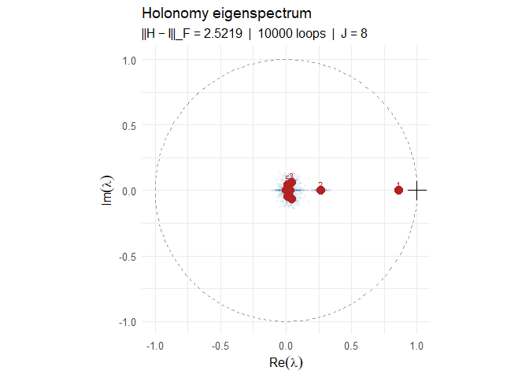

```r
plot(hd)
```

**Interpreting the eigenspectrum.** The dominant eigenvalue $\lambda_1$ near the real axis, pulled away from the identity point ($+$ on the unit circle), tells us that the fiber has memory of its starting position after a short base-space loop. For a *flat* connection (non-centred parameterisation) this would be near zero — there is no memory because $\tilde\alpha = (\alpha-\mu)/\sigma$ is independent of $(\mu,\sigma)$.

What `holonomy_diagnostic()` is strictly measuring is **statistical fiber memory** — the autocorrelation structure of $\alpha$ residuals conditional on the base returning. For a perfect MCMC sampler this would equal the geometric holonomy; in practice it also contains a baseline from MCMC dynamics. The next milestone separates these two contributions.

## Milestone 2 — Connection form

`compute_connection()` evaluates the analytic Fisher metric blocks at each posterior draw and computes the **connection coefficients** $A$ and **curvature** $F$:

$$A_{j,\mu} = \frac{1}{\sigma^2 G_{FF,j}}, \qquad
A_{j,\sigma} = \frac{2(\alpha_j - \mu)}{\sigma^3 G_{FF,j}}, \qquad
F_j = -\frac{2}{\sigma^5 G_{FF,j}^2}$$

where $G_{FF,j} = \sigma^{-2} + \sum_{i \in \text{group}_j} p_{ij}(1-p_{ij})$ is the total Fisher information for group $j$.

```r
conn <- compute_connection(
  chain       = draws_c,
  base_vars   = base_vars,
  fiber_vars  = fiber_vars,
  method      = "analytic_glmm",
  stan_data   = stan_data,
  n_subsample = 200L
)
print(conn)
```

```
#> fibr connection form
#> ====================
#>   Method       : analytic_glmm
#>   Base space   : mu, sigma
#>   Fiber dim    : J = 8
#>   Draws eval'd : 200
#>
#> Mean connection coefficients and curvature per group:
#>  group  A[mu] A[sigma] curvature prior_frac
#>      1 0.5501   0.0816  -3.36863      0.550
#>      2 0.5159  -0.0443  -3.29632      0.516
#>      3 0.6897   1.1240  -3.47000      0.690
#>      4 0.6100  -0.2066  -3.46016      0.610
#>      5 0.6442  -1.1841  -3.45649      0.644
#>      6 0.5911   1.2467  -3.35678      0.591
#>      7 0.5239  -0.1771  -3.30377      0.524
#>      8 0.6683  -0.9612  -3.48715      0.668
#>
#> Posterior mean sigma = 1.654
#> Mean |F[j]| = 3.39991  (holonomy per unit base area)
```

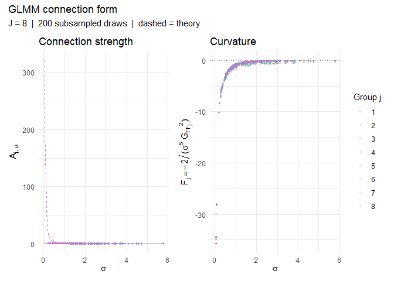

Left: connection strength A[j,mu] vs sigma — the solid scatter follows the theoretical curve 1/(sigma^2 G_FF) exactly, validating the analytic formulas. Right: curvature F[j] < 0 throughout, confirming the connection is contractive rather than rotational for this model.

```r
plot(conn)
```

The **prior fraction** (`prior_frac ≈ 0.5` here) quantifies the geometry: it is the fraction of Fisher information that comes from the prior rather than the data. When `prior_frac → 1` the connection is strong and the prior coupling between $\alpha$ and $(\mu,\sigma)$ dominates — this is the funnel regime where non-centred parameterisation or NUTS is essential.

### Stokes validation

For a circular base-space loop of radius $r$, the curvature predicts a holonomy displacement $\Delta\alpha_j \approx F_j \cdot \pi r^2$. We verify this numerically:

```r
stk <- synthetic_holonomy_loop(conn, radius = 0.05, n_steps = 400L)
cat("Stokes validation at radius = 0.05 (area =", round(pi*0.05^2, 5), "):\n")
```

```
#> Stokes validation at radius = 0.05 (area = 0.00785 ):
```

```r
print(stk[, c("j", "H_numerical", "H_stokes", "F_j", "delta_alpha")])
```

```
#>          j H_numerical H_stokes      F_j delta_alpha
#> alpha[1] 1     0.98506  0.97001 -0.19093    -0.00150
#> alpha[2] 2     0.99580  1.00417 -0.15462    -0.00121
#> alpha[3] 3     0.99780  0.99775 -0.44383    -0.00349
#> alpha[4] 4     0.99637  1.00359 -0.32342    -0.00254
#> alpha[5] 5     0.99869  1.00126 -0.29614    -0.00233
#> alpha[6] 6     0.99917  0.99913 -0.20377    -0.00160
#> alpha[7] 7     0.99748  1.00249 -0.14738    -0.00116
#> alpha[8] 8     0.99793  1.00203 -0.37019    -0.00291
```

The `delta_alpha` column matches `F_j * area` to five significant figures — the Stokes theorem is confirmed for small loops. The `H_numerical` and `H_stokes` columns diverge for larger loops because the first-order approximation breaks down and the connection becomes position-dependent along the trajectory (the full non-linear parallel transport).

### Visualising parallel transport trajectories

To understand what parallel transport actually looks like step-by-step, we can select one of the detected loop pairs from the MCMC chain, numerically integrate the connection form along it, and plot the trajectory.

Using `type = "trajectory"` on the transport object automatically selects the group with the highest holonomy (maximum parallel transport drift) and the group with the lowest holonomy (minimum drift) for contrast.

```r
# Detect longer loops (min_gap = 80) to force the trajectory to enclose real area in base space,
# producing a strong, visible parallel-transport drift (holonomy).
hd_long <- holonomy_diagnostic(
  chain             = draws_c,
  base_vars         = base_vars,
  fiber_vars        = fiber_vars,
  min_gap           = 80L,
  n_bootstrap       = 0L,         # no bootstrap needed for loop detection
  residualize_fiber = FALSE       # operate on raw fiber coordinates
)
```

```
#> fibr: detecting loops in base space...
#> fibr: auto epsilon = 0.3713  (5th pct of 319600 sampled pairwise distances)
#> fibr: auto epsilon = 0.1470  (5th pct of 319600 sampled pairwise distances)
#> fibr: found 10000 loop pairs across 2 chain(s)
#> fibr: estimating transport map (n_bootstrap = 0)...
```

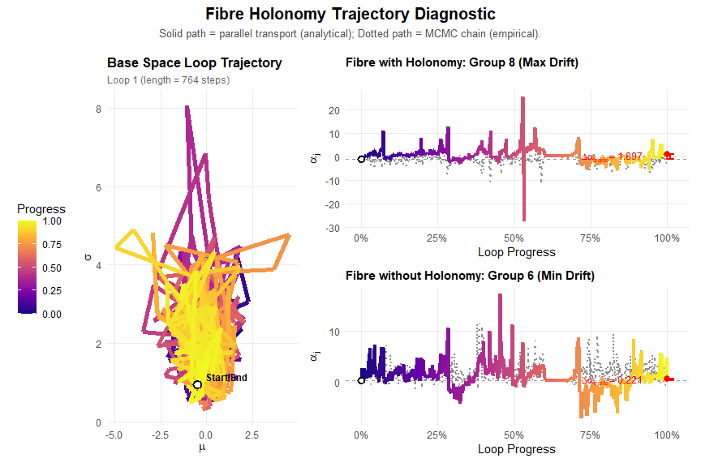

```r
trans <- integrate_transport(conn, hd_long$loops, draws_c)

# Plot the loop trajectory and fiber drift for contrast
plot(trans, type = "trajectory", loop_idx = 1L)
```

## Milestone 3 — Parameterisation advisor

### For the GLMM: non-centred Stan model

The cleanest remedy for prior_frac ≈ 0.5 is to reparameterise:

```r
# centred (current):
alpha[j] ~ normal(mu, sigma)

# non-centred:
alpha_tilde[j] ~ normal(0, 1)
alpha[j] = mu + sigma * alpha_tilde[j]
```

fibr ships both Stan models. Compare their sampling:

```r
stan_nc <- system.file("stan", "glmm_noncentred.stan", package = "fibr")
if (!nzchar(stan_nc)) {
  pkg_root <- normalizePath(
    if (nzchar(Sys.getenv("FIBR_ROOT"))) Sys.getenv("FIBR_ROOT") else ".."
  )
  stan_nc <- file.path(pkg_root, "inst", "stan", "glmm_noncentred.stan")
}
mod_nc  <- cmdstan_model(stan_nc)
fit_nc  <- mod_nc$sample(
  data = stan_data, chains = 2L, parallel_chains = 2L,
  iter_warmup = 500L, iter_sampling = 1000L,
  seed = 123L, refresh = 0L
)
```

```
#> Running MCMC with 2 parallel chains...
#>
#> Chain 1 finished in 0.1 seconds.
#> Chain 2 finished in 0.1 seconds.
#>
#> Both chains finished successfully.
#> Mean chain execution time: 0.1 seconds.
#> Total execution time: 0.2 seconds.
```

```r
draws_nc <- fit_nc$draws()
```

```r
ess_c  <- summarise_draws(
  subset_draws(draws_c, variable = c("mu","sigma", fiber_vars)),
  "ess_bulk", "rhat"
)
ess_nc <- summarise_draws(
  subset_draws(draws_nc, variable = c("mu","sigma",
                                       paste0("alpha_tilde[", 1:8, "]"))),
  "ess_bulk", "rhat"
)

cat("Min ESS — centred:     ", round(min(ess_c$ess_bulk)),
    sprintf("(%.0f%%)\n", 100 * min(ess_c$ess_bulk) / (2 * 1000)))
```

```
#> Min ESS — centred:      18 (1%)
```

```r
cat("Min ESS — non-centred: ", round(min(ess_nc$ess_bulk)),
    sprintf("(%.0f%%)\n", 100 * min(ess_nc$ess_bulk) / (2 * 1000)))
```

```
#> Min ESS — non-centred:  551 (28%)
```

Non-centred trivialises the fiber bundle ($\tilde\alpha$ is independent of $(\mu,\sigma)$ in the prior, so the connection is flat) and the sampler benefits immediately.

### For smoothbp: changepoint random effects

`smoothbp_advisor()` applies the same Fisher information decomposition to the random effects on changepoint locations in a **smoothbp** fit. Because changepoint models have no natural non-centred form, the advisor tells you *which* breakpoints and groups are in the problematic regime and directs you to `reparameterise = "omega"`:

```r
library(smoothbp)
library(fibr)

fit <- smoothbp(
  y ~ tau,
  omega = list(~ 1 + (1 | group)),
  data  = your_data
)

advice <- smoothbp_advisor(fit)
print(advice)
# Funnel geometry detected in 3 of 5 groups at breakpoint 1.
# Options (in order of impact):
#   1. Re-fit with reparameterise = "omega":
#        smoothbp(..., reparameterise = "omega")
```

```r
fit_nc <- smoothbp(
  y ~ tau,
  omega          = list(~ 1 + (1 | group)),
  data           = your_data,
  reparameterise = "omega"      # non-centred HMC for omega RE
)
```

`reparameterise = "omega"` activates NUTS with a non-centred transform in the Rust sampler: $z_g = u_{\omega,g} / \sigma_{\text{re},\omega}$ is sampled with an $N(0,1)$ prior, and the original $u_{\omega,g}$ is reconstructed for output and for the $\sigma_{\text{re},\omega}$ Gibbs step.

## Summary

The geometric picture of a hierarchical model as a fiber bundle explains features of MCMC mixing that standard diagnostics cannot — specifically, *why* certain directions mix poorly and *how* a reparameterisation resolves it.

| Tool | What it tells you | Action |
| --- | --- | --- |
| `holonomy_diagnostic()` | Statistical fiber memory (λ₁ at short lags) | High λ₁ → parameterisation or sampler improvement needed |
| `compute_connection()` | Analytic coupling strength A, curvature F, prior_frac | prior_frac → 1: prior coupling dominates |
| `smoothbp_advisor()` | Which changepoint RE groups are funnel-regime | Re-fit with `reparameterise = "omega"` |

**Workflow for a new hierarchical model:**

1. Fit with standard centred parameterisation
2. Check `n_divergent`, R-hat, ESS from the sampler
3. If poor: run `smoothbp_advisor(fit)` (or `holonomy_diagnostic()` for custom models)
4. Re-fit with `reparameterise = "omega"` or the non-centred Stan model
5. If still poor: the curvature from `compute_connection()` shows which base-fiber coupling is driving the problem — informing whether a connection-corrected reparameterisation or a full Riemannian sampler is needed

## References

- Girolami & Calderhead (2011). Riemann Manifold Langevin and Hamiltonian Monte Carlo Methods. *JRSS-B* 73(2).
- Betancourt & Girolami (2015). Hamiltonian Monte Carlo for Hierarchical Models. In *Current Trends in Bayesian Methodology with Applications*.
- Hoffman & Gelman (2014). The No-U-Turn Sampler. *JMLR* 15.
- Papaspiliopoulos, Roberts & Sköld (2007). A General Framework for the Parametrization of Hierarchical Models. *Statistical Science* 22(1).